# Problem Sets

## **Problem Set 10: Cluster Analysis**

### **Question 1**

#### Make dendrograms of the results of hierarchical clustering using the single, average and complete methods. Use the dune_bio.txt dataset after creating a Bray-Curtis distance matrix.

```r
dune_bio <- read.table("R10_cluster_analysis/data/dune_bio.txt", sep="\t", header = T, row.names = 1)
head(dune_bio)
```

```
##    Belper Empnig Junbuf Junart Airpra Elepal Rumace Viclat Brarut Ranfla Cirarv
## 2       3      0      0      0      0      0      0      0      0      0      0
## 13      0      0      3      0      0      0      0      0      0      2      0
## 4       2      0      0      0      0      0      0      0      2      0      2
## 16      0      0      0      3      0      8      0      0      4      2      0
## 6       0      0      0      0      0      0      6      0      6      0      0
## 1       0      0      0      0      0      0      0      0      0      0      0
##    Hyprad Leoaut Potpal Poapra Calcus Tripra Trirep Antodo Salrep Achmil Poatri
## 2       0      5      0      4      0      0      5      0      0      3      7
## 13      0      2      0      2      0      0      2      0      0      0      9
## 4       0      2      0      4      0      0      1      0      0      0      5
## 16      0      0      0      0      3      0      0      0      0      0      2
## 6       0      3      0      3      0      5      5      3      0      2      4
## 1       0      0      0      4      0      0      0      0      0      1      2
##    Chealb Elyrep Sagpro Plalan Agrsto Lolper Alogen Brohor
## 2       0      4      0      0      0      5      2      4
## 13      1      0      2      0      5      0      5      0
## 4       0      4      5      0      8      5      2      3
## 16      0      0      0      0      7      0      4      0
## 6       0      0      0      5      0      6      0      0
## 1       0      4      0      0      0      7      0      0
```

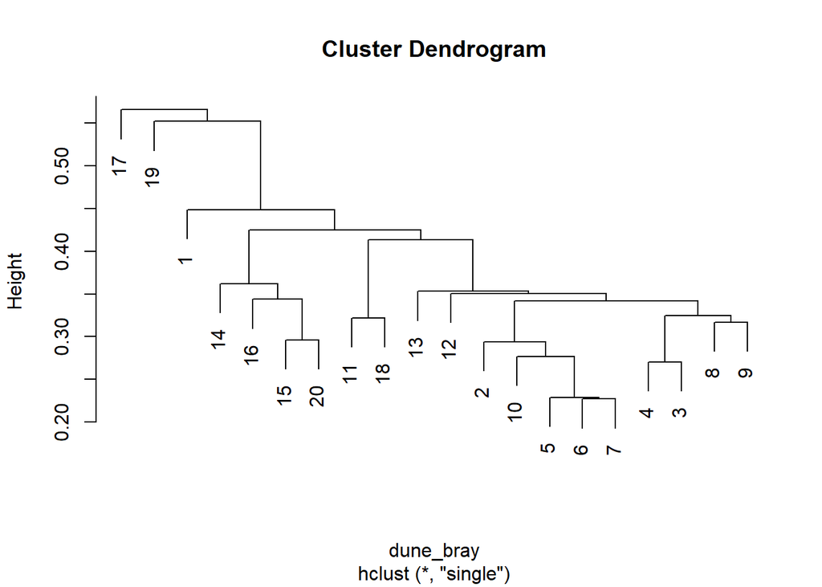

```r
#Hierarchical clustering
dune_bray<-vegdist(dune_bio, method="bray")

clust_single<-hclust(dune_bray, method="single")
clust_avg<-hclust(dune_bray, method="average")
clust_complete<-hclust(dune_bray, method="complete")

plot(clust_single) #dendrogram (tree) visualization
```

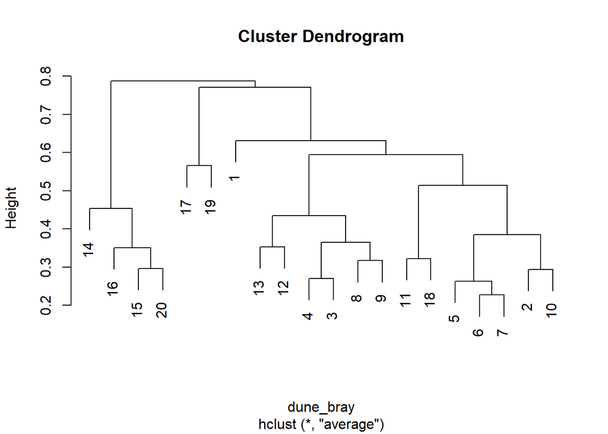

```r
plot(clust_avg)
```

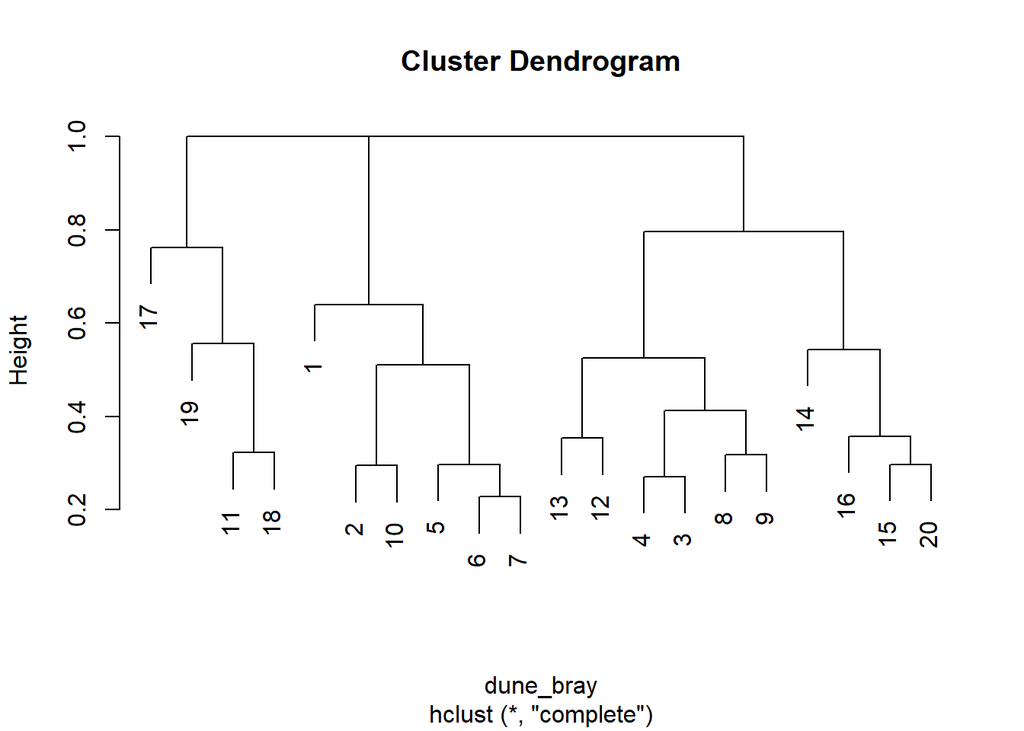

```r
plot(clust_complete)
```

### **Question 2**

#### Perform k-means partitions from 2 to 6 on the dune_bio.txt dataset and select the best partition using the Calinski criterion. Visualize the results.

```r
# Read in data
dune_bio <- read.table("R10_cluster_analysis/data/dune_bio.txt", sep="\t", header = T, row.names = 1)
head(dune_bio)
```

```
##    Belper Empnig Junbuf Junart Airpra Elepal Rumace Viclat Brarut Ranfla Cirarv
## 2       3      0      0      0      0      0      0      0      0      0      0
## 13      0      0      3      0      0      0      0      0      0      2      0
## 4       2      0      0      0      0      0      0      0      2      0      2
## 16      0      0      0      3      0      8      0      0      4      2      0
## 6       0      0      0      0      0      0      6      0      6      0      0
## 1       0      0      0      0      0      0      0      0      0      0      0
##    Hyprad Leoaut Potpal Poapra Calcus Tripra Trirep Antodo Salrep Achmil Poatri
## 2       0      5      0      4      0      0      5      0      0      3      7
## 13      0      2      0      2      0      0      2      0      0      0      9
## 4       0      2      0      4      0      0      1      0      0      0      5
## 16      0      0      0      0      3      0      0      0      0      0      2
## 6       0      3      0      3      0      5      5      3      0      2      4
## 1       0      0      0      4      0      0      0      0      0      1      2
##    Chealb Elyrep Sagpro Plalan Agrsto Lolper Alogen Brohor
## 2       0      4      0      0      0      5      2      4
## 13      1      0      2      0      5      0      5      0
## 4       0      4      5      0      8      5      2      3
## 16      0      0      0      0      7      0      4      0
## 6       0      0      0      5      0      6      0      0
## 1       0      4      0      0      0      7      0      0
```

```r
# Load packages
library(vegan)       # cluster analysis
library(tidyverse)   # data manipulation
library(fpc)         # calinski criterion

# Calculate the Bray-Curtis distance matrix
distance_matrix <- vegdist(dune_bio, method = "bray")

# Create an empty list to store k-means models
kmeans_models <- list()
calinski_scores <- c()

# Iterate through k = 2 to 6
for (k in 2:6) {
  # Perform k-means clustering using the distance matrix
  model <- kmeans(distance_matrix, centers = k)

  # Store the model in the list
  kmeans_models[[k - 1]] <- model

  # Calculate dissimilarity sums of squares between and within clusters
  cluster_diss <- cluster.stats(distance_matrix, model$cluster)

  # Calculate the Calinski-Harabasz index
  calinski <- cluster_diss$ch
  calinski_scores <- c(calinski_scores, calinski)
}

# Find the optimal number of clusters with the highest Calinski-Harabasz index
optimal_k <- which.max(calinski_scores) + 1

# Select the best k-means model
best_kmeans_model <- kmeans_models[[optimal_k - 1]]

# Output the optimal number of clusters and the best k-means model
optimal_k
```

```
## [1] 4
```

```r
best_kmeans_model
```

```
## K-means clustering with 4 clusters of sizes 6, 4, 2, 8
##
## Cluster means:
##           2        13         4        16         6         1         8
## 1 0.5041411 0.3456026 0.3499140 0.6016977 0.6308567 0.6658206 0.3106168
## 2 0.8835275 0.6631262 0.7405550 0.3111881 0.8270814 0.9803922 0.4771717
## 3 0.8163903 0.8437500 0.8447368 0.9531250 0.7020293 0.9393939 0.8186940
## 4 0.4071785 0.7268698 0.5310972 0.8862785 0.3666832 0.5257059 0.5822448
##           5        17        15        10        11         9        18
## 1 0.5818057 0.8952592 0.6398251 0.5906853 0.6146386 0.3003049 0.6905822
## 2 0.8789276 0.9263041 0.2537853 0.8490769 0.8133325 0.6927694 0.7798648
## 3 0.6616962 0.2826087 0.8362573 0.6616962 0.6288416 0.8377794 0.6568144
## 4 0.3868861 0.7205035 0.8392754 0.3389453 0.4196274 0.5682040 0.4710198
##           3        20        14        19        12         7
## 1 0.3002849 0.6908522 0.7018692 0.7762050 0.3514318 0.5440316
## 2 0.7275416 0.2736479 0.3400268 0.8201272 0.6502025 0.8735012
## 3 0.8609475 0.8274895 0.8759907 0.2826087 0.8084848 0.7096031
## 4 0.4925220 0.8704492 0.8468489 0.7236128 0.7159836 0.3400911
##
## Clustering vector:
##  2 13  4 16  6  1  8  5 17 15 10 11  9 18  3 20 14 19 12  7
##  4  1  1  2  4  4  1  4  3  2  4  4  1  4  1  2  2  3  1  4
##
## Within cluster sum of squares by cluster:
## [1] 1.5937748 0.6676346 0.4484247 2.9580899
##  (between_SS / total_SS =  70.5 %)
##
## Available components:
##
## [1] "cluster"      "centers"      "totss"        "withinss"     "tot.withinss"
## [6] "betweenss"    "size"         "iter"         "ifault"
```

## **Problem Set 11: Ordination**

### **Question 1**

#### Load the varechem dataset within the R package vegan. This data frame collects soil characteristics. Do the following:

```r
library(vegan)

# Load the varechem dataset
data(varechem)

# View
head(varechem)
```

```
##       N    P     K    Ca    Mg    S    Al   Fe    Mn   Zn  Mo Baresoil Humdepth
## 18 19.8 42.1 139.9 519.4  90.0 32.3  39.0 40.9  58.1  4.5 0.3     43.9      2.2
## 15 13.4 39.1 167.3 356.7  70.7 35.2  88.1 39.0  52.4  5.4 0.3     23.6      2.2
## 24 20.2 67.7 207.1 973.3 209.1 58.1 138.0 35.4  32.1 16.8 0.8     21.2      2.0
## 27 20.6 60.8 233.7 834.0 127.2 40.7  15.4  4.4 132.0 10.7 0.2     18.7      2.9
## 23 23.8 54.5 180.6 777.0 125.8 39.5  24.2  3.0  50.1  6.6 0.3     46.0      3.0
## 19 22.8 40.9 171.4 691.8 151.4 40.8 104.8 17.6  43.6  9.1 0.4     40.5      3.8
##     pH
## 18 2.7
## 15 2.8
## 24 3.0
## 27 2.8
## 23 2.7
## 19 2.7
```

```r
# Given the nature of this dataset perform a PCA or a CA ordination analysis.
varechem.pca <- rda(varechem)


# a) How much variation is explained by the two first axes?

# eigenvalues of the PCA
eigenvalues <- varechem.pca$CA$eig

# proportion of variation explained by each axis
summary(varechem.pca)
```

```
##
## Call:
## rda(X = varechem)
##
## Partitioning of variance:
##               Inertia Proportion
## Total           85655          1
## Unconstrained   85655          1
##
## Eigenvalues, and their contribution to the variance
##
## Importance of components:
##                             PC1       PC2       PC3       PC4       PC5
## Eigenvalue            6.406e+04 1.696e+04 2.425e+03 952.75912 7.162e+02
## Proportion Explained  7.478e-01 1.980e-01 2.832e-02   0.01112 8.362e-03
## Cumulative Proportion 7.478e-01 9.459e-01 9.742e-01   0.98533 9.937e-01
##                            PC6       PC7       PC8       PC9      PC10     PC11
## Eigenvalue            248.4113 1.960e+02 6.122e+01 2.293e+01 9.8096415 1.55e+00
## Proportion Explained    0.0029 2.288e-03 7.147e-04 2.677e-04 0.0001145 1.81e-05
## Cumulative Proportion   0.9966 9.989e-01 9.996e-01 9.999e-01 0.9999799 1.00e+00
##                            PC12      PC13      PC14
## Eigenvalue            1.536e-01 1.365e-02 6.111e-03
## Proportion Explained  1.794e-06 1.594e-07 7.134e-08
## Cumulative Proportion 1.000e+00 1.000e+00 1.000e+00
##
## Scaling 2 for species and site scores
## * Species are scaled proportional to eigenvalues
## * Sites are unscaled: weighted dispersion equal on all dimensions
## * General scaling constant of scores:  37.46449
##
##
## Species scores
##
##                 PC1       PC2       PC3       PC4       PC5       PC6
## N         1.848e-01   0.06565 -0.064579  0.242489  0.049798 -0.058950
## P        -1.406e+00  -0.49338 -0.586447  0.098794 -0.247471 -0.340161
## K        -5.590e+00  -2.71621 -5.415076  0.133394  0.441849  0.851878
## Ca       -3.107e+01  -2.16215  1.364667  0.031580 -0.392100  0.076706
## Mg       -4.214e+00  -0.62786 -0.292713  0.086101  2.889419 -0.946727
## S        -7.922e-01  -0.77736 -0.743928 -0.246051  0.306013 -0.229167
```

[output cut: 22 more lines]

```
## 13   0.829 -12.710 -20.68496  -0.1316   8.8986   5.5632
## 14   1.547   4.261   0.05426  -8.2069   1.5852   6.2083
## 20  -5.570   0.107  -3.92228  -0.1163  -9.1245  -7.3301
## 25  -2.990   8.022  -1.83433   7.3358 -14.9367 -12.3328
## 7   12.819  -6.135   4.23067  -1.3655   3.5539  -9.4099
## 5   10.191  10.296   6.17062  -3.8974  -4.1207   0.3553
## 6   10.185   2.024   7.11856   1.9300  -2.2812  -0.7472
## 3   12.217  -8.641   8.25696  16.1822   3.0774  -3.6812
## 4    2.654 -17.193  -7.52309 -13.6917 -10.8525  -4.5842
## 2    5.225 -11.817   1.62040  16.6311  -0.2547   8.4378
## 9    2.630  -3.420   3.06818 -12.4091  -4.8046 -11.7627
## 12   3.026   3.760   2.34446  -8.5600  -2.3325   5.4528
## 10  -4.452  -2.765  -2.98307  -5.1036  -1.3049   4.8802
## 11 -17.513 -12.376  17.78560   0.9704  -9.2785  12.4853
## 21   2.380   8.025   5.05469  -4.2513   4.0366   4.6918
```

```r
(prop.var <- round(eigenvalues/sum(eigenvalues)*100, 1))
```

```
##  PC1  PC2  PC3  PC4  PC5  PC6  PC7  PC8  PC9 PC10 PC11 PC12 PC13 PC14
## 74.8 19.8  2.8  1.1  0.8  0.3  0.2  0.1  0.0  0.0  0.0  0.0  0.0  0.0
```

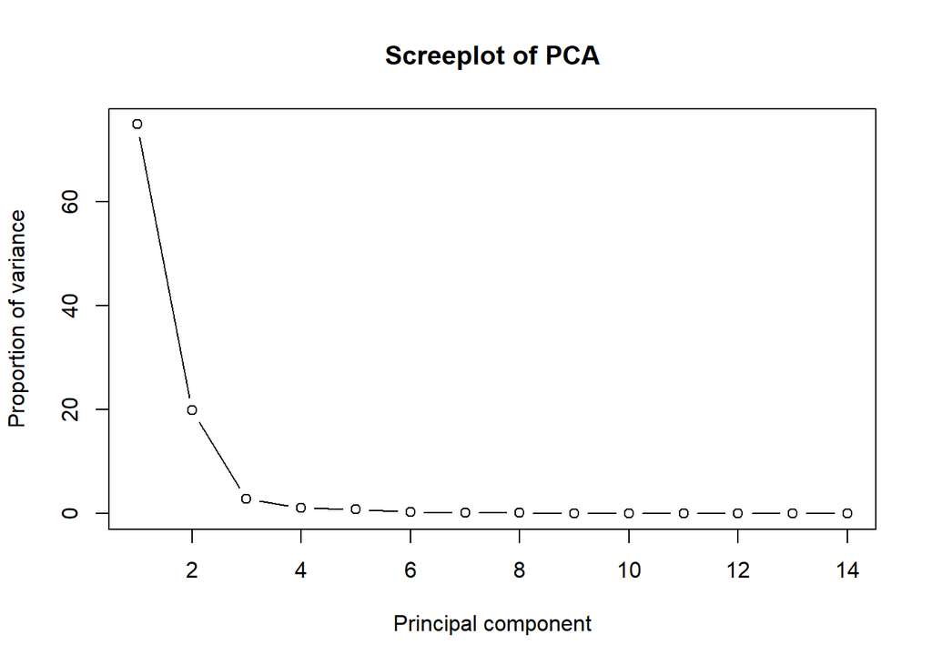

```r
# b) Make a screeplot of the results
plot(prop.var, type = "b", xlab = "Principal component", ylab = "Proportion of variance", main = "Screeplot of PCA")
```

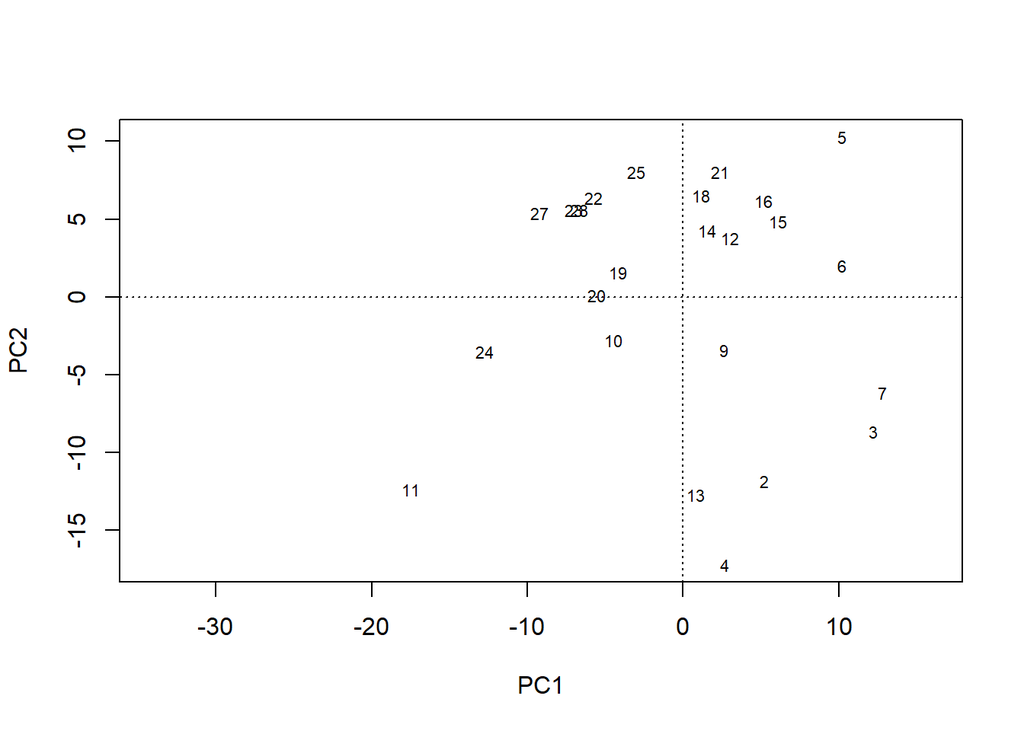

```r
# c) Plot the ordination results of the sites
plot(varechem.pca, type = "n")
text(varechem.pca, display = "sites", cex = 0.7)
```

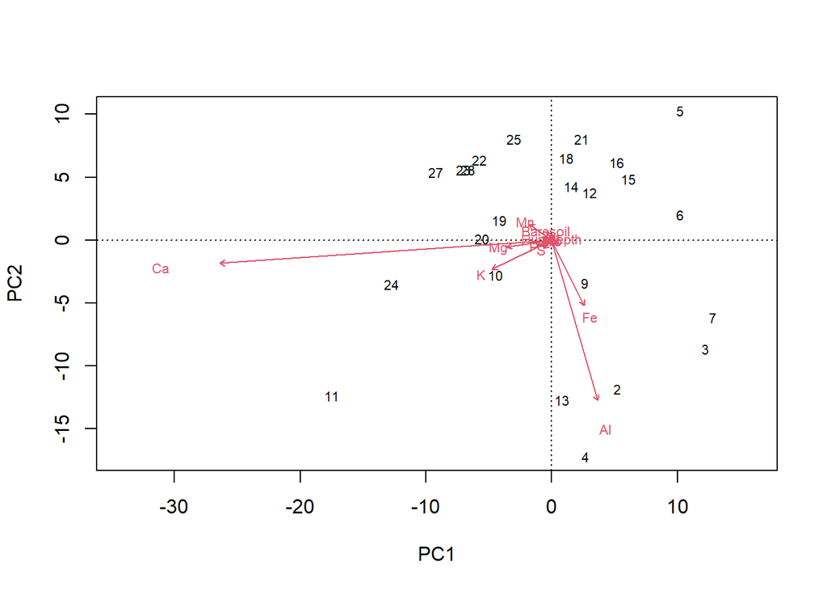

```r
# d) Plot both the sites scores and the soil characteristics scores focusing on the soil variables
biplot(varechem.pca, scaling = 2)
```

### **Question 2**

#### The dune_bio.txt dataset corresponds to species abundances. Given the nature of this dataset perform a PCA or a CA ordination analysis.

```r
# Read in data
dune_bio <- read.table("R10_cluster_analysis/data/dune_bio.txt", sep="\t", header = T, row.names = 1)

# Load vegan library
library(vegan)

# Perform CA
dune.ca <- cca(dune_bio)

# a) How much variation is explained by the two first axes?
# Proportion of variation explained by each axis
summary(dune.ca)
```

```
##
## Call:
## cca(X = dune_bio)
##
## Partitioning of scaled Chi-square:
##               Inertia Proportion
## Total           2.115          1
## Unconstrained   2.115          1
##
## Eigenvalues, and their contribution to the scaled Chi-square
##
## Importance of components:
##                          CA1    CA2    CA3     CA4     CA5     CA6     CA7
## Eigenvalue            0.5360 0.4001 0.2598 0.17598 0.14476 0.10791 0.09247
## Proportion Explained  0.2534 0.1892 0.1228 0.08319 0.06844 0.05102 0.04372
## Cumulative Proportion 0.2534 0.4426 0.5654 0.64858 0.71702 0.76804 0.81175
##                           CA8     CA9    CA10    CA11    CA12    CA13     CA14
## Eigenvalue            0.08091 0.07332 0.05630 0.04826 0.04125 0.03523 0.020529
## Proportion Explained  0.03825 0.03466 0.02661 0.02282 0.01950 0.01665 0.009705
## Cumulative Proportion 0.85000 0.88467 0.91128 0.93410 0.95360 0.97025 0.979955
##                           CA15     CA16     CA17     CA18     CA19
## Eigenvalue            0.014911 0.009074 0.007938 0.007002 0.003477
## Proportion Explained  0.007049 0.004290 0.003753 0.003310 0.001644
## Cumulative Proportion 0.987004 0.991293 0.995046 0.998356 1.000000
##
## Scaling 2 for species and site scores
## * Species are scaled proportional to eigenvalues
## * Sites are unscaled: weighted dispersion equal on all dimensions
##
##
## Species scores
##
##             CA1      CA2      CA3       CA4       CA5      CA6
## Belper -0.50018 -0.35503 -0.15239 -0.704153 -0.058546 -0.07308
## Empnig -0.69027  3.26420  1.95716 -0.176936 -0.073518  0.16083
## Junbuf  0.08157 -0.68074  1.00545  1.078390  0.268360 -0.24168
## Junart  1.27580  0.09963 -0.09320  0.005536  0.289410  0.78247
## Airpra -1.00434  3.06749  1.33773  0.194305 -1.081813  0.53699
## Elepal  1.76383  0.34562 -0.57336 -0.002976 -0.332396  0.14688
## Rumace -0.65289 -0.25525 -0.59728  1.160164  0.255849  0.32730
```

[output cut: 33 more lines]

```
## 1  -0.81167 -1.0826714 -0.14479 -2.10665 -0.39287  1.83462
## 8   0.76268 -0.2968459  0.35648 -0.10772  0.17507  0.36444
## 5  -0.95293 -0.1846015 -0.95609  0.86853 -0.34552  0.98333
## 17 -1.47545  2.7724102  0.40859  0.75117 -2.59425  1.10122
## 15  1.91384  0.5079036 -0.96567  0.04227 -0.50681 -0.19370
## 10 -0.87885 -0.0353136 -0.82987 -0.68053 -0.75438 -0.81070
## 11 -0.64223  0.4440332 -0.17371 -1.09684  1.37462 -2.00626
## 9   0.09693 -0.7864314  0.86492  0.40090  0.28704  1.02783
## 18 -0.31241  0.6328355 -0.66501 -1.12728  2.65575 -0.97565
## 3  -0.10148 -0.9128732  0.68815 -0.68137 -0.08709  0.28678
## 20  1.94438  1.0688809 -0.66595 -0.55317  1.59606  1.70292
## 14  1.91996  0.5351062 -1.39863 -0.08575 -2.21317 -2.43044
## 19 -0.69027  3.2642026  1.95716 -0.17694 -0.07352  0.16083
## 12  0.28557 -0.6656161  1.64423  1.71496  0.65381 -1.17376
## 7  -0.87149 -0.2547040 -0.86830  0.90468  0.17385  0.03446
```

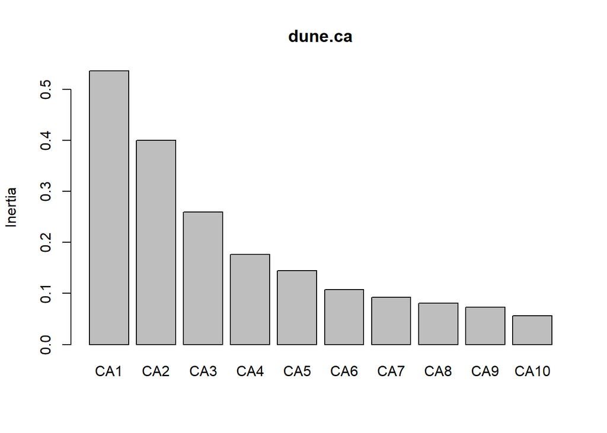

```r
# b) Make a screeplot of the results
screeplot(dune.ca)
```

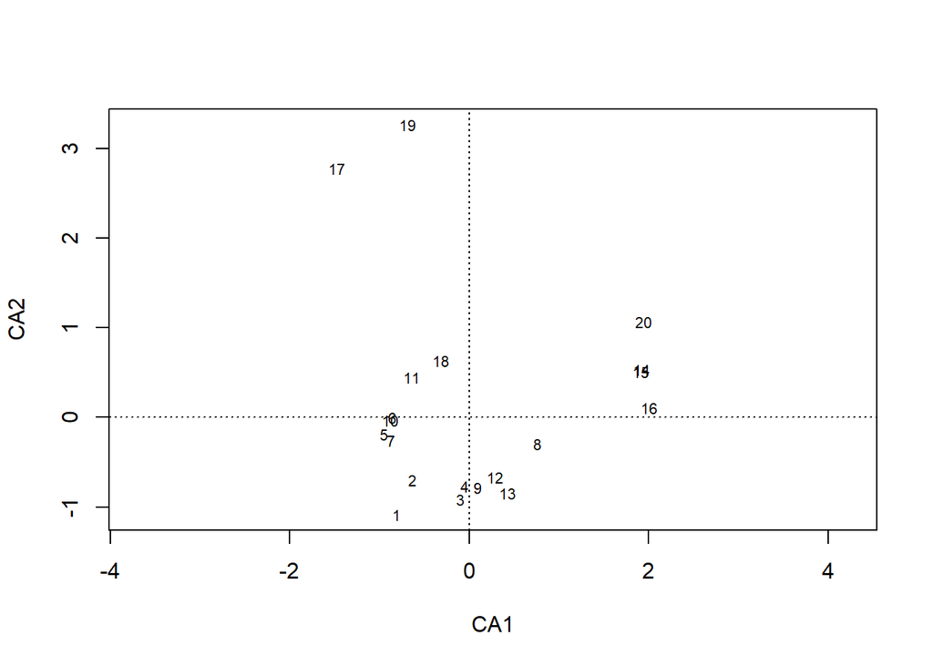

```r
# c) Plot the ordination results of the sites
plot(dune.ca, display = "sites")
```

### **Question 3**

#### Perform a nonmetric multidimensional scaling (NMDS) on the dune_bio.txt dataset after calculating Bray-Curtis distances among sites.

```r
# Read in data
dune_bio <- read.table("R11_ordination/data/dune_bio.txt", sep="\t", header = T, row.names = 1)

# Calculate Bray-Curtis dissimilarity matrix
dune_dist <- vegdist(dune_bio, method = "bray")

# Perform NMDS
set.seed(123)
dune_nmds <- metaMDS(dune_dist, k = 2, trymax = 100)
```

```
## *** Best solution repeated 4 times
```

```r
# a) What is the stress?
dune_nmds$stress
```

```
## [1] 0.1183186
```

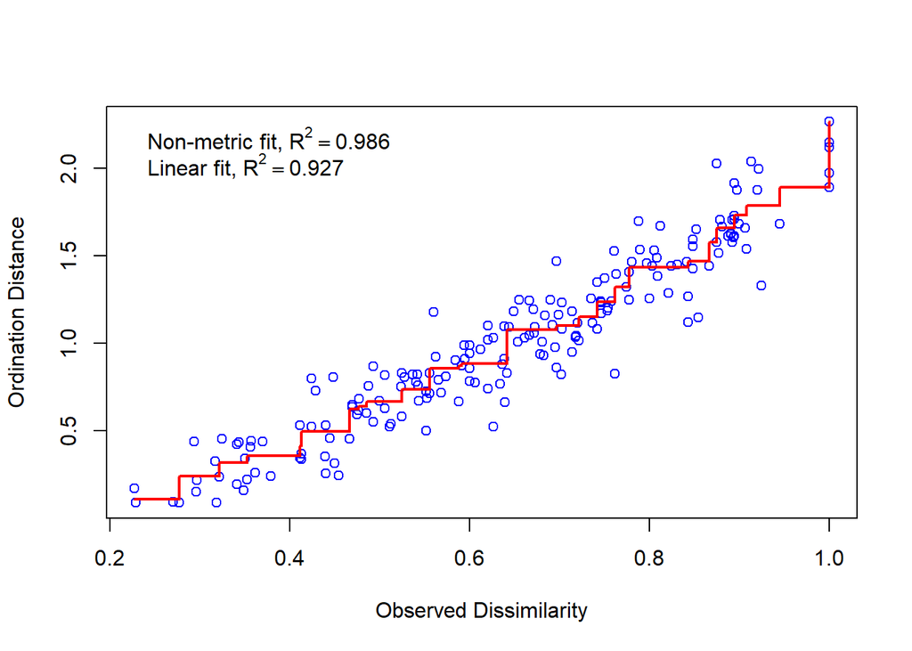

```r
# b) Make a Shepard plot of the NMDS results
stressplot(dune_nmds)
```

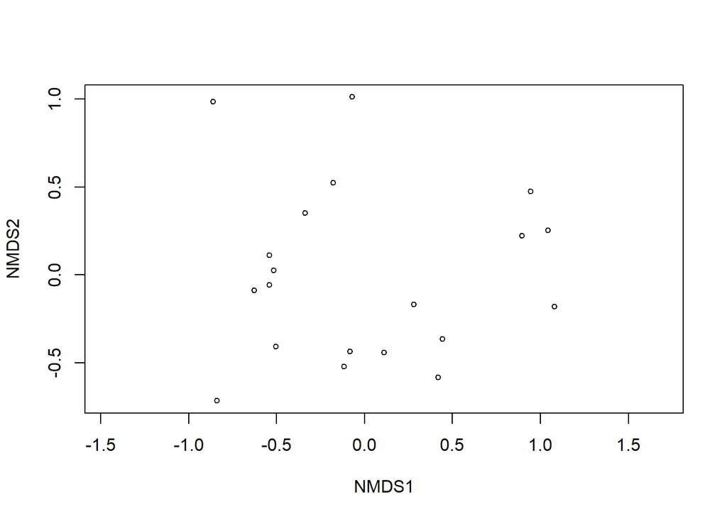

```r
# c) Plot the ordination results of the sites
plot(dune_nmds, display = "sites")
```

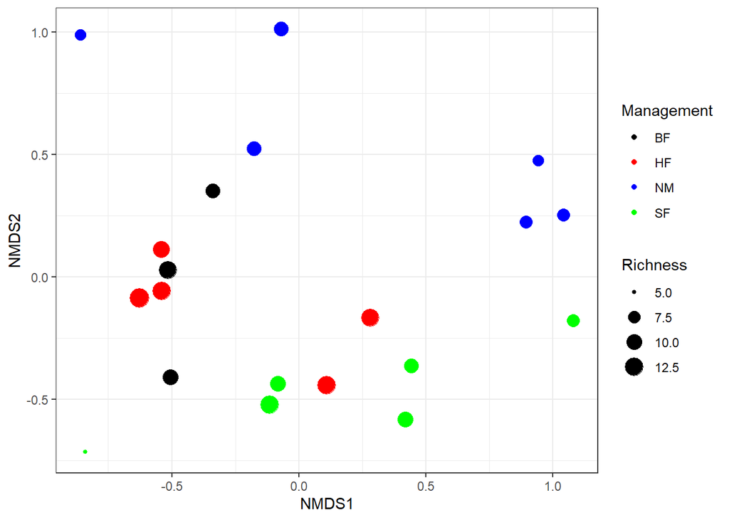

```r
# d) [Advanced – ggplot2] Plot the ordination results using ggplot2.
#    Use the dune_env.txt dataset to make the size of the points
#    proportional to the site richness (number of species) and
#    the color to represent the variable Management.

# Load ggvegan package
library(ggvegan)

# Load data
dune_env <- read.table("R11_ordination/data/dune_env.txt", sep="\t", header = T, row.names = 1)

# Extract site scores from NMDS object and name columns
dune_scores <- data.frame(NMDS1 = dune_nmds$points[,1], NMDS2 = dune_nmds$points[,2])

# Add site richness and Management variables
dune_scores$Richness <- rowSums(dune_bio > 0)
dune_scores$Management <- dune_env$Management

# Plot using ggplot2
ggplot(dune_scores, aes(x = NMDS1, y = NMDS2)) +
  geom_point(aes(size = Richness, color = Management)) +
  scale_color_manual(values = c("black", "red", "blue", "green")) +
  labs(x = "NMDS1", y = "NMDS2", size = "Richness", color = "Management") +
  theme_bw()
```

### **Question 4**

#### Perform a constrained correspondence analysis (CCA) on the dune_bio.txt dataset using the first (A1), second (Moisture) and fifth (Manure) variables of dune_env.txt as explanatory.

```r
# Load packages
library(vegan)

# Read in data
dune_bio <- read.table("R11_ordination/data/dune_bio.txt", sep="\t", header = T, row.names = 1)

# Perform CCA
dune_cca <- cca(dune_bio ~ A1 + Moisture + Manure, data = dune_env)

# a) Variation explained by first two constrained axes
dune_cca$CCA
```

```
## $eig
##      CCA1      CCA2      CCA3
## 0.4264268 0.2346962 0.1081232
##
## $poseig
## NULL
##
## $u
##          CCA1        CCA2        CCA3
## 2  -1.0721645 -0.15064571  0.02248439
## 13  1.3313412  1.08879312 -0.17909863
## 4  -0.4031599  1.49565056 -0.09656978
## 16  1.2911794  1.04854117 -0.34917010
## 6  -0.9650664 -0.04330717  0.47600830
## 1  -1.0994893  1.27128858 -0.50140763
## 8   1.0903705  0.84728141 -1.19952742
## 5  -0.6973213  0.22503917  1.60981806
## 17 -0.5627064 -1.56289510  0.04416645
## 15  1.9680612 -0.44703770  3.12946612
## 10 -0.6232242 -0.89888856 -0.41619626
## 11 -1.1053575 -0.90857346  0.08601369
## 9   0.4481405 -0.77218022 -0.96709228
## 18 -0.9912907 -1.51891073  0.77313836
## 3  -0.3897726  1.50906787 -0.03987929
## 20  0.8970807 -1.52042308 -1.40577293
## 14  1.6735416 -0.74221868  1.88227538
## 19  0.9238553 -1.49358844 -1.29239196
## 12  0.7624658  0.26751119  0.15987867
## 7  -1.1326823  0.51336083 -0.43787833
##
## $v
##               CCA1        CCA2        CCA3
## Belper -1.11035852  0.18609025  0.87213139
## Empnig  1.41475642 -3.08303103 -3.93038265
## Junbuf  0.77405428  0.36113967 -1.08590959
## Junart  1.66068409 -0.45604291 -1.00505278
## Airpra  0.50417108 -3.14025552 -2.30450253
## Elepal  2.13249526  0.04059818  1.21182929
## Rumace -0.87235194  0.16009955  1.34775799
## Viclat -1.46445244 -2.18541973  0.40217143
```

[output cut: 93 more lines]

```
## $rank
## [1] 3
##
## $qraux
## [1] 1.157638 1.207313 1.400020
##
## $pivot
## [1] 1 2 3
##
## attr(,"class")
## [1] "qr"
##
## $envcentre
##       A1 Moisture   Manure
## 4.684964 2.801460 1.902190
```

```r
# b) Adjusted R2 of the model
RsquareAdj(dune_cca)$adj.r.squared
```

```
## [1] 0.2452277
```

```r
# c) Permutation test for overall statistical significance
anova(dune_cca)
```

```
## Permutation test for cca under reduced model
## Permutation: free
## Number of permutations: 999
##
## Model: cca(formula = dune_bio ~ A1 + Moisture + Manure, data = dune_env)
##          Df ChiSquare     F Pr(>F)
## Model     3   0.76925 3.048  0.001 ***
## Residual 16   1.34602
## ---
## Signif. codes:  0 '***' 0.001 '**' 0.01 '*' 0.05 '.' 0.1 ' ' 1
```

```r
# d) Permutation test for marginal statistical significance of explanatory variables
anova(dune_cca, by="margin")
```

```
## Permutation test for cca under reduced model
## Marginal effects of terms
## Permutation: free
## Number of permutations: 999
##
## Model: cca(formula = dune_bio ~ A1 + Moisture + Manure, data = dune_env)
##          Df ChiSquare      F Pr(>F)
## A1        1   0.13047 1.5508  0.106
## Moisture  1   0.30886 3.6714  0.001 ***
## Manure    1   0.23418 2.7837  0.002 **
## Residual 16   1.34602
## ---
## Signif. codes:  0 '***' 0.001 '**' 0.01 '*' 0.05 '.' 0.1 ' ' 1
```

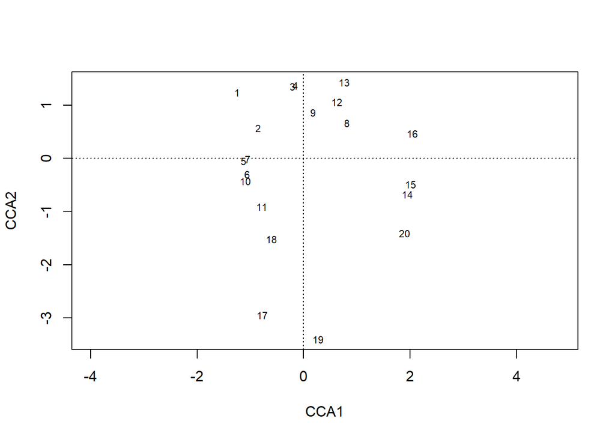

```r
# e) Triplot of ordination results focusing on sites
plot(dune_cca, display = "sites")
```

### **Question 5**

#### Perform a permutational multivariate analysis of variance (PERMANOVA) with 9,999 permutations using the dune_bio.txt dataset after calculating Bray-Curtis distances and the first (A1), second (Moisture) and fifth (Manure) variables of dune_env.txt as explanatory.

```r
# Load packages
library(vegan)

# Read in data
dune_bio <- read.table("R11_ordination/data/dune_bio.txt", sep = "\t", header = TRUE, row.names = 1)
dune_env <- read.table("R11_ordination/data/dune_env.txt", sep = "\t", header = TRUE)

# Convert Use variable to a factor
dune_env$Use <- factor(dune_env$Use)

# Calculate Bray-Curtis distances
dune_bc <- vegdist(dune_bio, method = "bray")

# Perform PERMANOVA with A1, Moisture, and Manure as explanatory variables
dune_perm <- adonis2(dune_bc ~ A1 + Moisture + Manure, data = dune_env, permutations = 9999)

# a) Which explanatory variables are significant?
print(summary(dune_perm))
```

```
##        Df          SumOfSqs            R2               F
##  Min.   : 1.0   Min.   :0.7197   Min.   :0.1674   Min.   :5.788
##  1st Qu.: 1.0   1st Qu.:0.7230   1st Qu.:0.1682   1st Qu.:5.802
##  Median : 1.0   Median :0.8670   Median :0.2017   Median :5.815
##  Mean   : 7.6   Mean   :1.7196   Mean   :0.4000   Mean   :6.192
##  3rd Qu.:16.0   3rd Qu.:1.9893   3rd Qu.:0.4627   3rd Qu.:6.394
##  Max.   :19.0   Max.   :4.2990   Max.   :1.0000   Max.   :6.974
##                                                   NA's   :2
##      Pr(>F)
##  Min.   :0.00010
##  1st Qu.:0.00015
##  Median :0.00020
##  Mean   :0.00020
##  3rd Qu.:0.00025
##  Max.   :0.00030
##  NA's   :2
```

```r
# b) What is the explanatory power (R2) of the significant variables?
print(dune_perm$R2)
```

```
## [1] 0.1681666 0.2016854 0.1674089 0.4627391 1.0000000
```

```r
# c) Perform a new PERMANOVA analysis with 9,999 permutations
# with A1 as the explanatory variable but constrain the permutations within the Use variable.
dune_perm2 <- adonis2(dune_bc ~ A1, data = dune_env, permutations = 9999, strata = dune_env$Use)

# Print results of PERMANOVA with constrained permutations
print(summary(dune_perm2))
```

```
##        Df           SumOfSqs           R2               F
##  Min.   : 1.00   Min.   :0.723   Min.   :0.1682   Min.   :3.639
##  1st Qu.: 9.50   1st Qu.:2.150   1st Qu.:0.5000   1st Qu.:3.639
##  Median :18.00   Median :3.576   Median :0.8318   Median :3.639
##  Mean   :12.67   Mean   :2.866   Mean   :0.6667   Mean   :3.639
##  3rd Qu.:18.50   3rd Qu.:3.938   3rd Qu.:0.9159   3rd Qu.:3.639
##  Max.   :19.00   Max.   :4.299   Max.   :1.0000   Max.   :3.639
##                                                   NA's   :2
##      Pr(>F)
##  Min.   :0.0062
##  1st Qu.:0.0062
##  Median :0.0062
##  Mean   :0.0062
##  3rd Qu.:0.0062
##  Max.   :0.0062
##  NA's   :2
```

```r
# d) Plot a NMDS ordination to visually confirm your results in c).
# ggplot2 extension to plot ordination:
# https://github.com/gavinsimpson/ggvegan
# install.packages("remotes")
# remotes::install_github("gavinsimpson/ggvegan")
# library(ggvegan)
# library(ggfortify)
# autoplot(dune_perm2)

# That didn't work, so...


# d) Plot a NMDS ordination to visually confirm your results in c).
# Perform NMDS ordination
dune_nmds <- metaMDS(dune_bio, distance = "bray")
```

```
## *** Best solution repeated 6 times
```

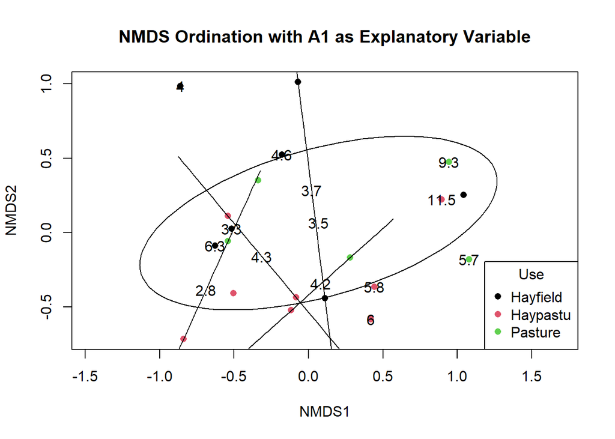

```r
# Add environmental variables to the ordination plot
ordiplot(dune_nmds, display = "sites", type = "n")
points(dune_nmds, display = "sites", col = as.numeric(dune_env$Use), pch = 16)
ordiellipse(dune_nmds, dune_env$A1, kind = "se", conf = 0.95, label = TRUE)
# Add title and legend to the plot
title(main = "NMDS Ordination with A1 as Explanatory Variable")
legend("bottomright", legend = levels(dune_env$Use), col = 1:length(levels(dune_env$Use)), pch = 16, title = "Use")
```